# weekly_july3

Dohun Lee

2022-07-14

This is a RMDmarkdown to track and show progress between 13/07/22 ~ 27/07/22.

These were the main things to tackle:

1. Absolute ratio 0~1
2. ichorCNA: correlation between liquidCNA and ichorCNA’s optimichorCNA & CTC_count
3. Compare the absolute ratios between timely batch 2 options
4. RECIST: look at metastatic data; look at progression; evaluate whether subclonality tells us anything; compare subclonality between Y and N metastasis

# 1. Absolute ratio 0~1

### Patient 3080 | patient with extreme absolute sub-clonality estimation:

```r
liquidCNA_results$patient_3080
```

```
##      time         relratio              rat           rat_sd purity_mean
## 1 Sample3 0.86965558464975 8.47355873449432 1.58345586022625        0.13
## 2 Sample2                1 9.74634357458251 1.78007901062353        0.07
## 3 Sample1                0                0                0        0.05
##   purity_median seg_used cutOff
## 1         0.245       25    0.3
## 2          0.07       25    0.3
## 3          0.05       25    0.3
```

### I think the extreme absolute subclonality ratio is coming from extreme deltaCN values

```r
head(seg.dcn.toUse.46)
```

```
##       Sample3    Sample2
## 1  10.5037937  12.635239
## 2  10.6236352  12.513129
## 4 -12.0265727 -13.242563
## 5   0.6779776   1.024608
## 6 -11.8246368 -12.767660
## 7  11.1478483  13.070224
```

### The extreme deltaCN seems to come from low purity…

### The three time samples have the following purity estimates:

```r
pVec.46
```

```
## [1] 0.05 0.07 0.13
```

### This results the sample with low purity to have extreme CNS when corrected by purity.

### Before correction the segment CN values look normal…

```r
head(seg.cns.46)
```

```
##    Sample1  Sample2  Sample3
## 1 1.371152 2.004080 1.730489
## 2 1.366683 1.989275 1.734448
## 3 2.019916 2.063101 2.033835
## 4 2.742167 2.112054 2.366179
## 5 1.952375 2.005047 1.964311
## 6 2.745858 2.150465 2.402029
```

### However, with correction…

```r
head(seg.cns.corr.46)
```

```
##      Sample1  Sample2     Sample3
## 1 -10.576953 2.058286 -0.07315924
## 2 -10.666340 1.846789 -0.04270458
## 3   2.398312 2.901436  2.26027197
## 4  16.843336 3.600773  4.81676317
## 5   1.047492 2.072100  1.72546964
## 6  16.917166 4.149506  5.09252909
```

### The equation they correct CNS with purity by: **(((CNS-2)*1/purity)+2)**

### If we correct the CNS value of the first segment for each sample…

```r
(1.371152    - 2)/0.05 + 2 #Sample1
```

```
## [1] -10.57696
```

```r
(2.004080 - 2)/0.07 + 2 #Sample2
```

```
## [1] 2.058286
```

```r
(1.730489 - 2)/0.13 + 2 #Sample3
```

```
## [1] -0.07316154
```

### This results dCN to be extreme

```r
head(seg.dcn.46)
```

```
##   Sample1     Sample2     Sample3
## 1       0  12.6352387  10.5037937
## 2       0  12.5131288  10.6236352
## 3       0   0.5031239  -0.1380404
## 4       0 -13.2425631 -12.0265727
## 5       0   1.0246081   0.6779776
## 6       0 -12.7676596 -11.8246368
```

### So it seems that the extreme subclonality estimates are coming from low purity and purity-corrected CNS rather than the GMM fitting step

## Take the samples where sub-ratio is outside [0,1] and check the corresponding purity:

Majority of the error looks to come from small purity values. Currently, 31 out of 283 estimates are outside [0,1]; this is from 22/80 patients. Additionally, only 23 of the estimates linked with RECIST are outside the boundary.

```r
rats <- unlist(sapply(1:length(liquidCNA_results),
                      function(x) as.numeric(liquidCNA_results[[x]]$rat)))
purities <- unlist(sapply(1:length(liquidCNA_results),
                          function(x) as.numeric(liquidCNA_results[[x]]$purity_mean)))

# 31/283 estimations have sub-clonality ratio outside of [0,1]
out.rats<- which(rats < 0 | rats > 1)
length(out.rats)
```

```
## [1] 31
```

```r
is.out.rat <- function(x){
  rats <- as.numeric(liquidCNA_results[[x]]$rat)
  return(any(rats < 0 | rats > 1))
}

# 22/80 patients have sub-clonality ratio outside of [0,1]
out.rat.patients <- which(sapply(1:length(liquidCNA_results), function(x) is.out.rat(x)))
length((out.rat.patients))
```

```
## [1] 22
```

```r
#purities of out.rats
rats[out.rats]
```

```
##  [1] 1.110760 1.484909 1.593358 1.389029 1.292059 1.686263 1.164457 1.811724
##  [9] 1.477231 1.206072 1.288886 1.040109 1.268736 1.131115 1.009573 8.473559
## [17] 9.746344 1.154383 1.644420 1.183017 2.581482 1.374887 1.057119 1.227743
## [25] 1.285324 1.081085 1.495673 1.113131 1.064325 1.328851 1.179254
```

```r
purities[out.rats]
```

```
##  [1] 0.090 0.360 0.050 0.050 0.055 0.050 0.050 0.165 0.360 0.095 0.055 0.050
## [13] 0.050 0.170 0.050 0.130 0.070 0.090 0.050 0.050 0.440 0.050 0.050 0.050
## [25] 0.050 0.175 0.150 0.055 0.060 0.060 0.385
```

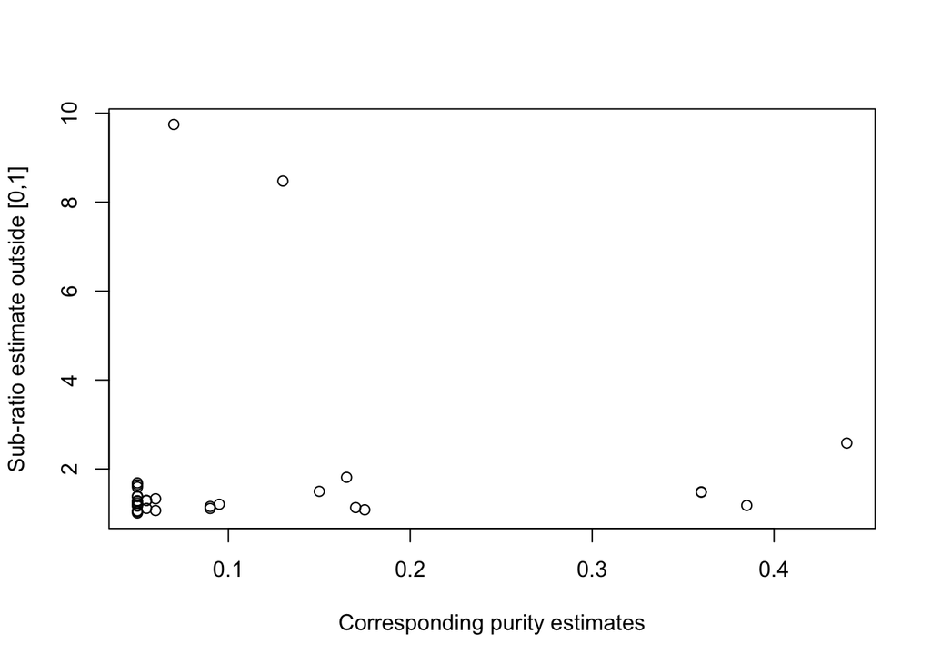

```r
plot(purities[out.rats], rats[out.rats],
     ylab = "Sub-ratio estimate outside [0,1]",
     xlab = "Corresponding purity estimates")
```

```r
out.results <- sapply(out.rat.patients, function(x) liquidCNA_results[[x]], simplify = F)
names(out.results) <- paste0("patient_", patient_ids[out.rat.patients])
```

Feedback: “it would be nice to see what causes the high-purity samples in your plot to fail as well? You can focus on the 2-3 with the highest purity and investigate them further.”

## Investigating why purities are failing:

### idea 1: when one of the samples have drastically lower purity

```r
out.results$patient_3614
```

```
##      time          relratio               rat            rat_sd purity_mean
## 1 Sample3 0.498681586968614 0.815406233134759  0.11763824770728        0.43
## 2 Sample2                 1  1.49567259622457 0.129331328770106        0.15
## 3 Sample1                 0                 0                 0        0.49
##   purity_median seg_used cutOff
## 1          0.43       65   0.24
## 2          0.15       65   0.24
## 3         0.495       65   0.24
```

Purity values:

```r
pVec.58
```

[output not shown]

Again, the dCN values for the erroneous sample are at a greater scale.

```r
head(seg.dcn.toUse.58)
```

```
##       Sample3   Sample2
## 4  0.14544862 2.4674319
## 5  0.35196059 6.2056043
## 7  0.02776333 0.8135755
## 11 0.14727313 1.9618118
## 12 0.07713489 0.6785464
## 14 0.03324136 1.3835290
```

### If we look at segment CN values, we can see that the CN states are at a drastically different range. This is resulted during the renomarlisation stage (where the centre of CN is recentred to be exactly 2).

Could we trim them out? not consider these segments? I tried setting the maximum CN value to be 6 (as the CN states considered during purity estimation are 5 CN states anyways). Whilst this method did not ‘save’ the result for patient 3614, it did bring down the absolute subclonality estimation to be near 1 (so I believe it would save the result for less drastic patients). One thing is, this seems like I am disturbing high quality sample (high purity) to fit well with lower quality samples (low purity).

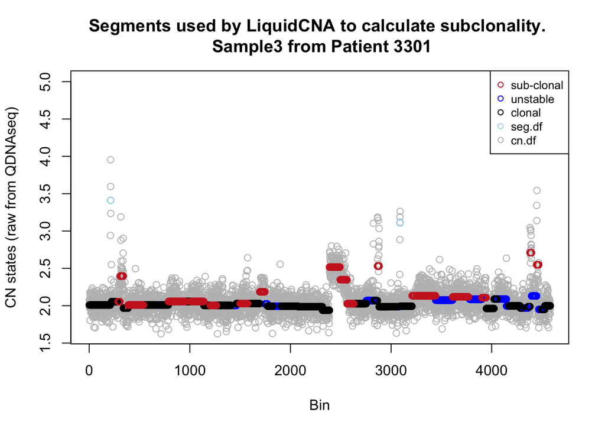

```r
plot.3C(3, cn.df.58, seg.df.58, seg.sub.58, seg.plot.58, 3301)
```

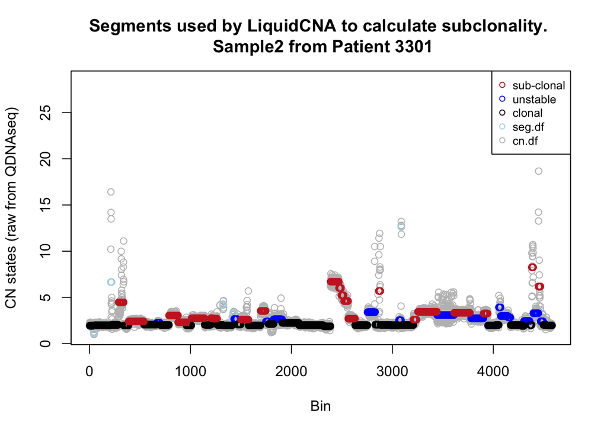

```r
plot.3C(2, cn.df.58, seg.df.58, seg.sub.58, seg.plot.58, 3301)
```

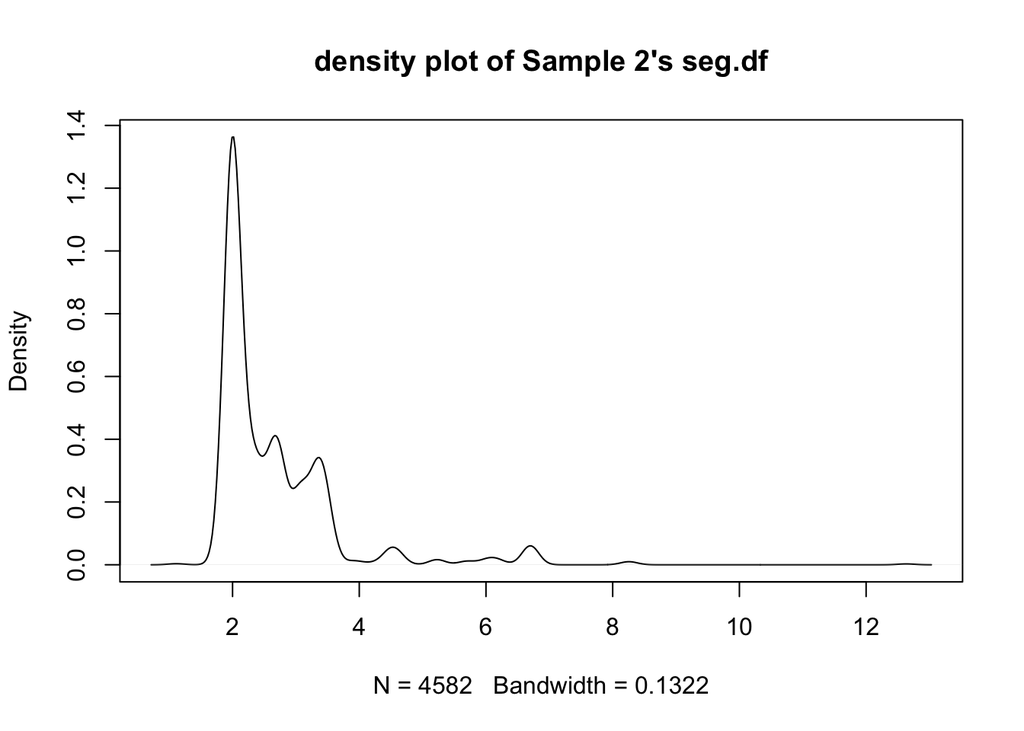

```r
plot(density(seg.df.58[,2]), main = "density plot of Sample 2's seg.df")
```

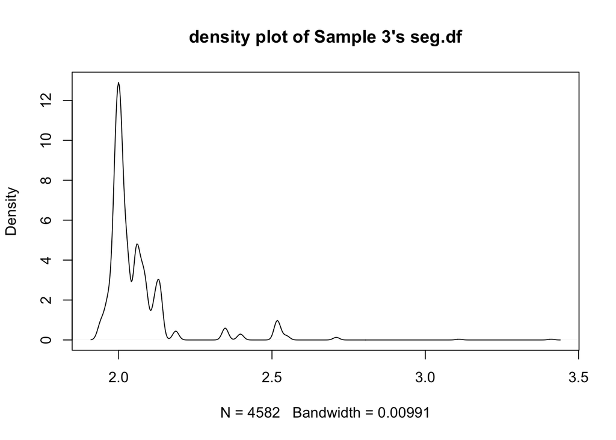

```r
plot(density(seg.df.58[,3]), main = "density plot of Sample 3's seg.df")
```

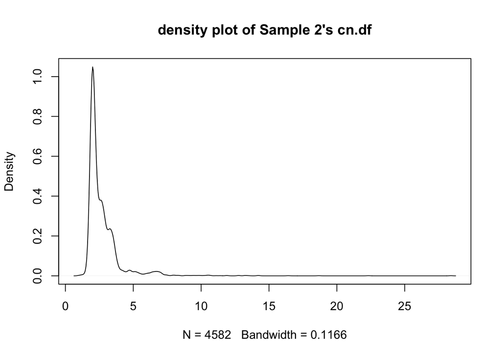

```r
plot(density(cn.df.58[,2]), main = "density plot of Sample 2's cn.df")
```

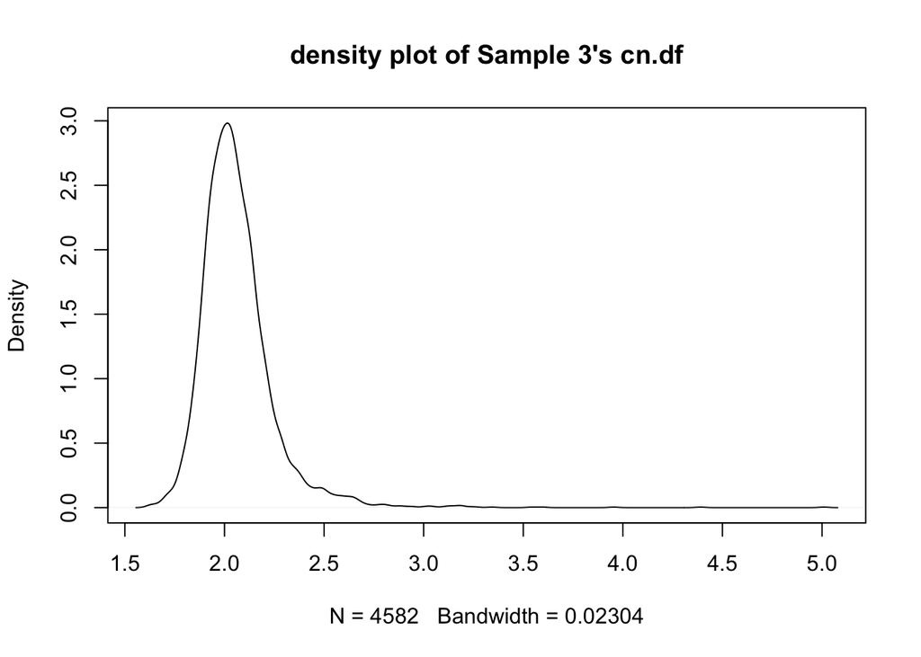

```r
plot(density(cn.df.58[,3]), main = "density plot of Sample 3's cn.df")
```

# 2. ichorCNA

### ichorCNA prediction of purity versus liquidCNA

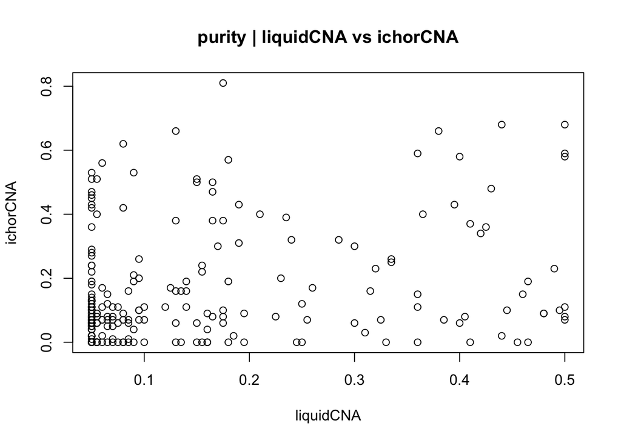

```r
optimichor <- ichorCNA$OptimichorCNA
ctc_count <- ichorCNA$CTC_count

ichorCNA.sorted <- ichorCNA[order( ichorCNA$Patient_ID, ichorCNA$Date ),]

ichor.purities <- ichorCNA.sorted$OptimichorCNA
ichor.purities <- ichor.purities / 100

plot(purities, ichor.purities, xlab = "liquidCNA", ylab = "ichorCNA",
     main = "purity | liquidCNA vs ichorCNA")
```

### Circulating tumor cell (CTC) count

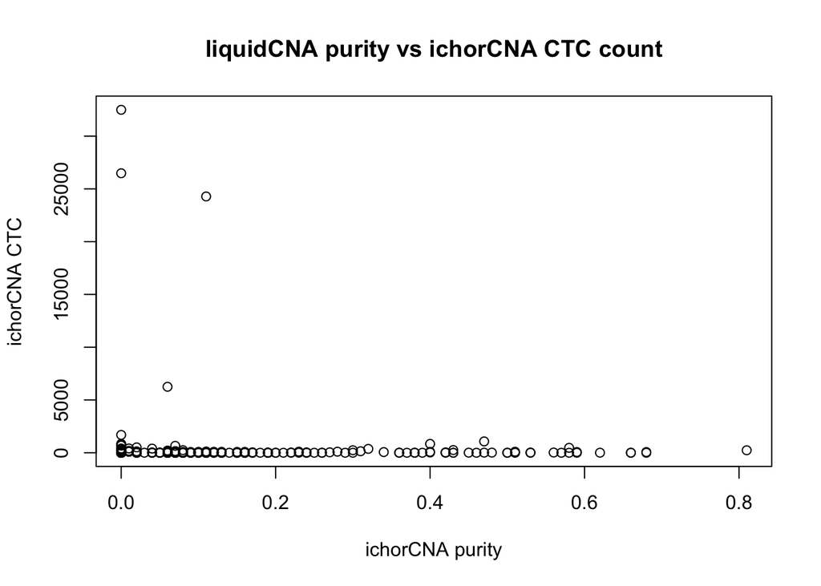

```r
plot(ichor.purities, ctc_count, xlab = "ichorCNA purity", ylab = "ichorCNA CTC",
     main = "liquidCNA purity vs ichorCNA CTC count")
```

# 4. Linking with RECIST

For each patient, build.df() builds a dataframe with 6 information:

1. Whether there is a change in progression + 1 is always progression + 0 is always stable + -1 is mix of progression and stable
2. Patient alive? 1 is yes, 0 is deceased
3. Purity Boolean. purity, is overall increasing or decreasing over time samples? Boolean of is increasing? 1 is yes, 0 is no (decreasing)
4. Purity. how much does purity change between first blood draw and last?
5. Sub-clone Boolean. whether sub-clonality overall decreased or increased over time samples. boolean of is increasing? 1 is yes, 0 is no (decreasing)
6. Subclone. absolute change in sub-clonality between first blood draw and last.

```r
head(c.df)
```

```
##             p.progression OS purity.increasing purity.change
## patient_339 -1            1  0                 0
## patient_388 -1            0  0                 -0.08
## patient_392 -1            0  1                 0.31
## patient_715 -1            0  1                 0.035
## patient_840 -1            0  0                 -0.015
## patient_957 -1            0  0                 -0.015
##             subclone.increasing subclone.change
## patient_339 0                   0.0433889
## patient_388 0                   0.04970095
## patient_392 1                   1.484909
## patient_715 0                   0.3322964
## patient_840 1                   1.292059
## patient_957 0                   0.3410267
```